# Analysis of Johnston Draw soil moisture

## Goal: Quantify the annual the effect of aspect on soil moisture in Johnston Draw

Data source S. E. Godsey, D. Marks, P. Kormos, M. Seyfried, Enslin, C., J. McNamara and T. Link, 2017, Eleven years of mountain weather, snow, soil moisture and stream flow data from the rain-snow transition zone - the Johnston Draw catchment, Reynolds Creek Experimental Watershed and Critical Zone Observatory, USA, Ag Data Commons, USDA Agricultural Library, http://dx.doi.org/10.15482/USDA.ADC/1402076.

#### Rough map of soil moisture probes in Johnston Draw (# 1-5)

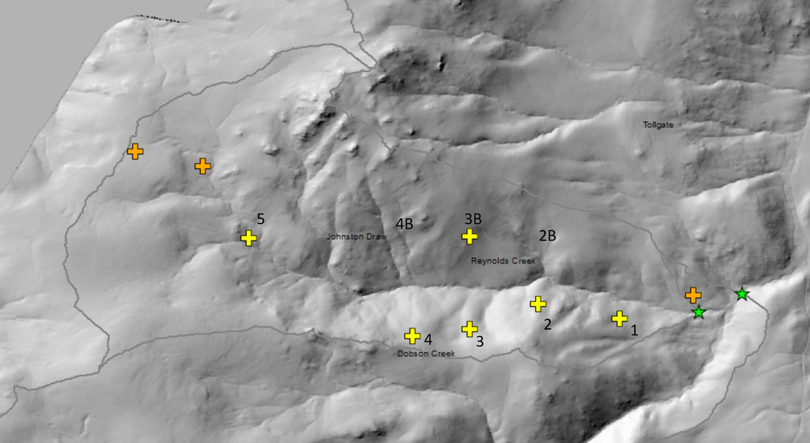

#### Part 1: Prepare soil moisture probe data

```r
# Function to read, clean and make daily averages from the raw soil moisture data files
get_daily_JD_sm <- function(file_loc) {

  loc_name <- strsplit(file_loc, "[.]")[[1]][4]
  print(loc_name)

  #read in file
  raw_soil_mst <- read.csv(file_loc, as.is=T)

  #format date
  raw_soil_mst$form_Date <- as.POSIXct(raw_soil_mst$Date_time)

  #remove rows with missing near surface values
  clean_soil_mst <- raw_soil_mst %>% filter(s_m_5 != -9999 &
                                            s_m_20 != -9999) # &
                                            #s_m_50 != -9999 &
                                            #s_m_75 != -9999)

  #get daily avg soil moisture
  dayavg_soil_mst <- clean_soil_mst %>% group_by(WY, Year, Month, Day) %>% summarise_all(mean)

  #remove if not a full day
  dayavg_soil_mst <- dayavg_soil_mst %>% filter(Hour == 11.5)

  #rebuild full date column
  dayavg_soil_mst$Date_time <- as.Date(with(dayavg_soil_mst, paste(Year, Month, Day,sep="-")), "%Y-%m-%d")

  #get monthly avg
  #monthavg_soil_mst <- dayavg_soil_mst %>% group_by(WY, Year, Month) %>% summarise_all(mean)

  #remove if not close to a full month
  #monthavg_soil_mst <- monthavg_soil_mst %>% filter(Day > 14 & Day < 17)

  #rebuild full date column
  #monthavg_soil_mst$Date_time <- as.Date(with(monthavg_soil_mst, paste(Year, Month, 1, sep="-")), "%Y-%m-%d")

  dayavg_soil_mst$Site <- loc_name

  output_df <- dayavg_soil_mst %>% select(Site, WY, Year, Month, Date_time, s_m_5, s_m_20, T_g_5, T_g_20)

  return(as.data.frame(output_df))
}


### Use ftn to compile the soil moisture data into one dataframe

#set path to soil moisture data
jd_soilmst_data_path <- "C:/Users/derek/Google Drive/RCrk/RC_SoDaH/RC_data/ARS_climate/Godsey JDraw Soil Moisture/raw data/"

#get ARS siol moisture data files from path
soil_mst_files <- list.files(jd_soilmst_data_path)
soil_mst_files <- soil_mst_files[!soil_mst_files %in% c('desktop.ini')]
path_soil_mst_files <- paste0(jd_soilmst_data_path, soil_mst_files)

loc_ids <- sapply(strsplit(soil_mst_files, "[.]"), "[[", 4)

#test for a single file/site
ftn_out_test <- get_daily_JD_sm(path_soil_mst_files[1])

#Compile from all ARS files
JD_sm_df <- sapply(path_soil_mst_files, get_daily_JD_sm, simplify=FALSE)
JDSM <- do.call(bind_rows, JD_sm_df)
```

**Click to see head of soil moisture table**

Daily soil moisture from Johnston Draw probes

| Site | WY | Year | Month | Date_time | s_m_5 | s_m_20 | T_g_5 | T_g_20 |
| --- | --- | --- | --- | --- | --- | --- | --- | --- |
| jd-124ba_stm | 2011 | 2010 | 11 | 2010-11-23 | 0.175 | 0.302 | 1.600 | 2.646 |
| jd-124ba_stm | 2011 | 2010 | 11 | 2010-11-24 | 0.174 | 0.300 | 1.600 | 2.587 |
| jd-124ba_stm | 2011 | 2010 | 11 | 2010-11-25 | 0.173 | 0.300 | 1.600 | 2.567 |
| jd-124ba_stm | 2011 | 2010 | 11 | 2010-11-26 | 0.174 | 0.299 | 1.550 | 2.496 |
| jd-124ba_stm | 2011 | 2010 | 11 | 2010-11-27 | 0.174 | 0.298 | 1.579 | 2.454 |
| jd-124ba_stm | 2011 | 2010 | 11 | 2010-11-28 | 0.175 | 0.298 | 1.579 | 2.404 |
| jd-124ba_stm | 2011 | 2010 | 11 | 2010-11-29 | 0.174 | 0.298 | 1.571 | 2.367 |
| jd-124ba_stm | 2011 | 2010 | 11 | 2010-11-30 | 0.174 | 0.298 | 1.521 | 2.346 |
| jd-124ba_stm | 2011 | 2010 | 12 | 2010-12-01 | 0.175 | 0.298 | 1.521 | 2.333 |
| jd-124ba_stm | 2011 | 2010 | 12 | 2010-12-02 | 0.176 | 0.299 | 1.504 | 2.292 |

[1] “Continues for 12058 rows”

### Johnston Draw 2

- Plot comparison of soil moisture for north and south aspect
- Calculate daily avg difference between aspects
- Summarize aspect difference by month

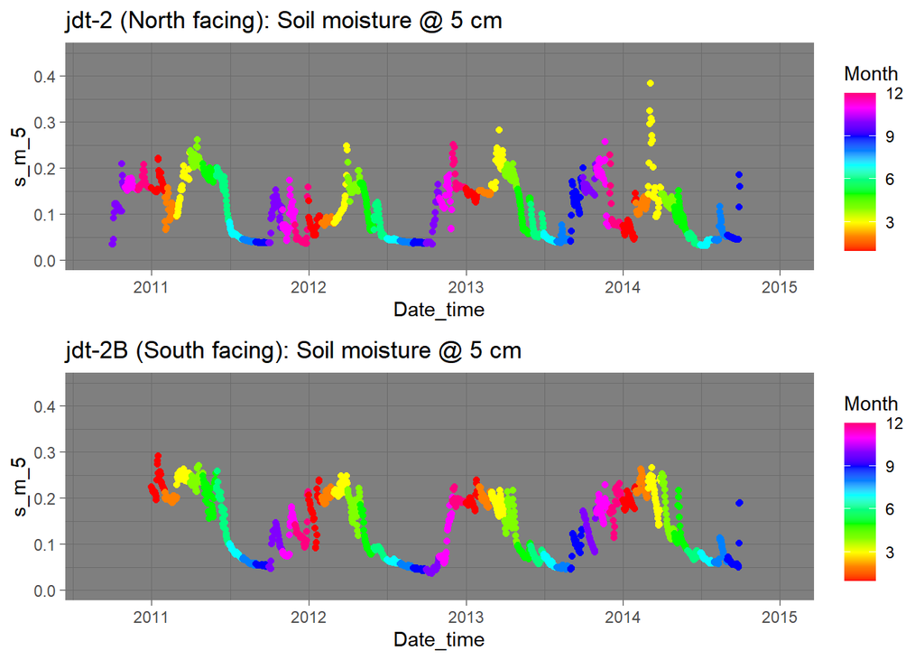

```r
jd2 <- ggplot(JDSM %>% filter(Site == "jd-jdt2_stm"), aes(x=Date_time, y=s_m_5, color=Month)) + geom_point() +
  scale_color_gradientn(colors = rainbow(12)) + theme_dark() +
  xlim(c(as.Date('2010-09-1', format = "%Y-%m-%d"), as.Date('2015-01-01', format = "%Y-%m-%d"))) +
  ylim(0,0.45) +
  ggtitle("jdt-2 (North facing): Soil moisture @ 5 cm") #+
  #theme(legend.position = "none")

jd2b <- ggplot(JDSM %>% filter(Site == "jd-jdt2b_stm"), aes(x=Date_time, y=s_m_5, color=Month)) + geom_point() +
  scale_color_gradientn(colors = rainbow(12)) + theme_dark() +
  xlim(c(as.Date('2010-09-1', format = "%Y-%m-%d"),as.Date('2015-01-01', format = "%Y-%m-%d"))) +
  ylim(0,0.45) +
  ggtitle("jdt-2B (South facing): Soil moisture @ 5 cm")


#Calculate diff

jd2_df <- JDSM %>% filter(Site == "jd-jdt2_stm") %>% select(Date_time, Month, s_m_5) %>% rename(jd2_sm5 = s_m_5)
jd2b_df <- JDSM %>% filter(Site == "jd-jdt2b_stm") %>% select(Date_time, Month, s_m_5) %>% rename(jd2b_sm5 = s_m_5)
jd2_merge_df <- left_join(jd2_df, jd2b_df) %>% na.omit()
jd2_merge_df$diff <- jd2_merge_df$jd2_sm5 - jd2_merge_df$jd2b_sm5


jd2_diff <- ggplot(jd2_merge_df, aes(x=Date_time, y=diff, color=Month)) + geom_point() +
  scale_color_gradientn(colors = rainbow(12)) + theme_dark() +
  xlim(c(as.Date('2010-09-1', format = "%Y-%m-%d"),as.Date('2015-01-01', format = "%Y-%m-%d"))) +
  ylim(-0.16,0.16) +
  ggtitle("jdt-2 (Difference: North-South): Soil moisture @ 5 cm") +
  geom_hline(yintercept=0, linetype="dashed", color = "black", size=2, alpha=0.5)

#Monthly average diff

jd2_monthly_diff <- jd2_merge_df %>% select(Month, diff) %>% group_by(Month) %>%
                      summarize(diff_avg = mean(diff),
                                diff_sd = sd(diff))

jd2_monthly_diff_plot <- ggplot(jd2_monthly_diff, aes(x=Month, y=diff_avg, fill=Month)) + geom_bar(stat = "identity") +
  scale_fill_gradientn(colors = rainbow(12)) + theme_dark() +
  scale_x_continuous(breaks=seq(1,12,1)) +
  geom_errorbar(aes(ymin=diff_avg-diff_sd, ymax=diff_avg+diff_sd), alpha=0.3, width=0.2) +
  ggtitle("jdt-2 (Difference: North - South): Soil moisture @ 5 cm") +
  geom_hline(yintercept=0, linetype="solid", color = "black", size=2, alpha=0.5) +
  theme(axis.line = element_line(colour = "black"),
    panel.grid.major = element_blank(),
    panel.grid.minor = element_blank()) +
  geom_text(x=6, y=-0.12, label="South slope wetter") +
  geom_text(x=6, y=0.12, label="North slope wetter") +
  ylim(-0.16,0.16)

grid.arrange(jd2, jd2b, ncol = 1)
```

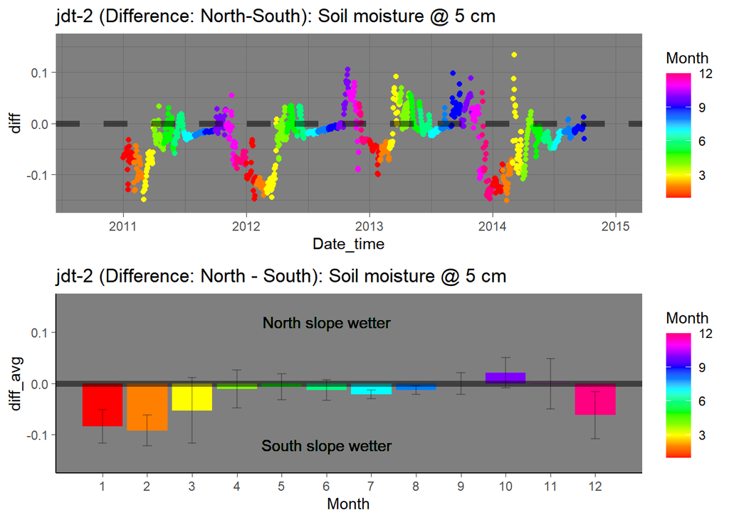

```r
grid.arrange(jd2_diff, jd2_monthly_diff_plot, ncol = 1)
```

### Johnston Draw 3

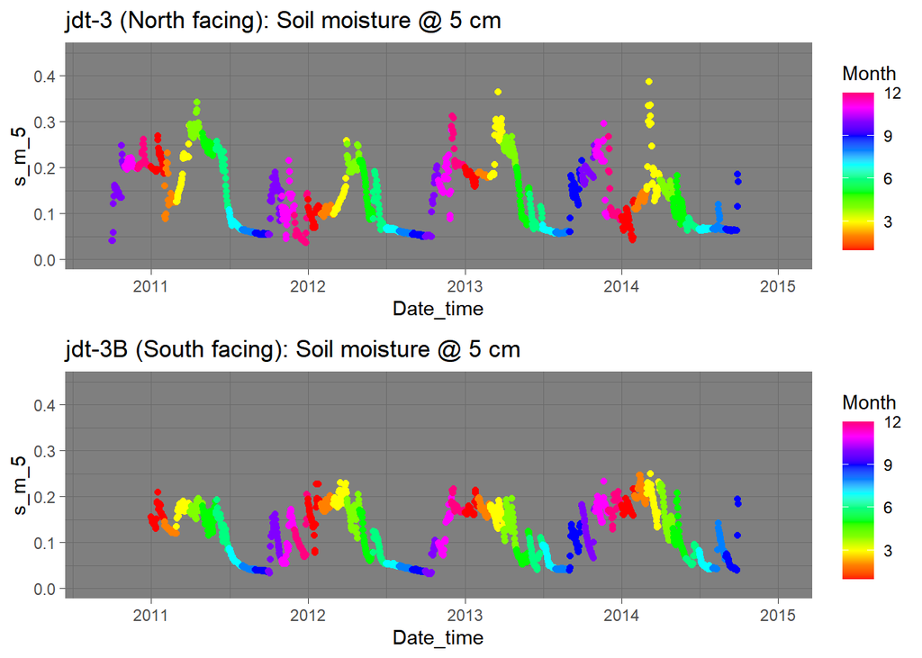

[figure not shown]

### Johnston Draw 4

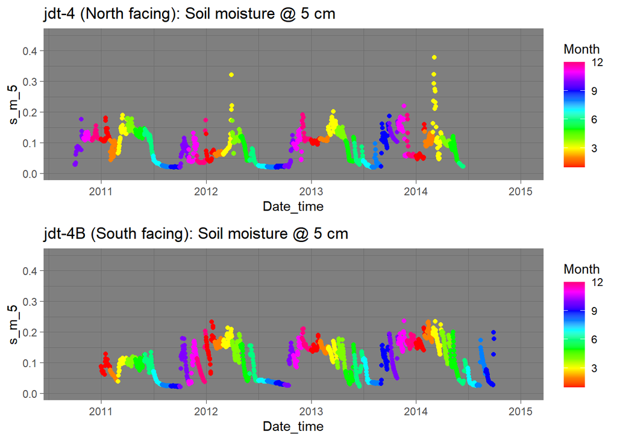

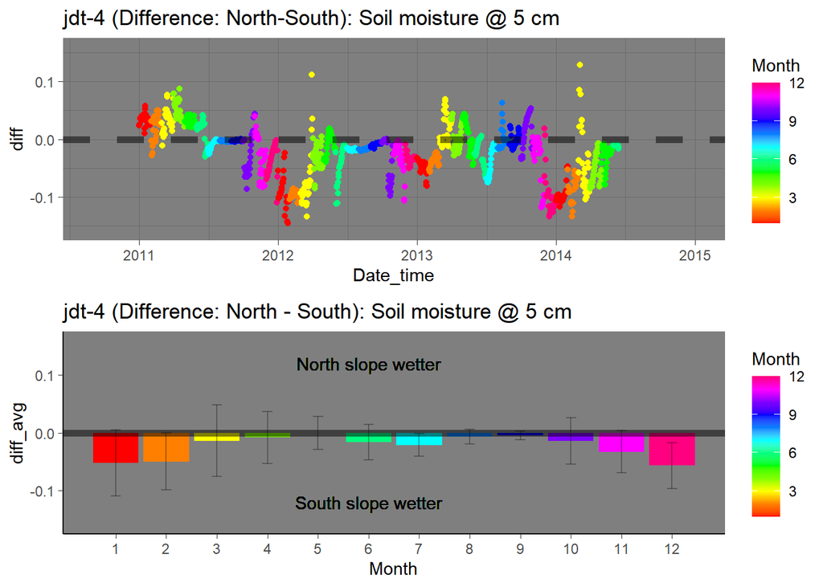

### No growing season diff in soil moisture @ JD2 and JD4…

#### …but I can see the veg difference…?

Johnston Draw: July 27, 2018

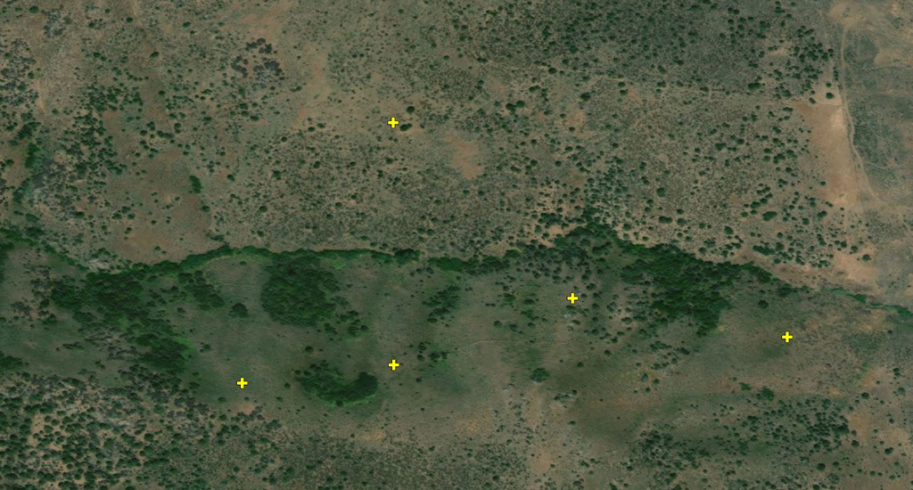

Soil Moisture Probe Locations

### Soil water @ 20 cm

#### maybe 5 cm was too shallow to observe soil moisture diff?

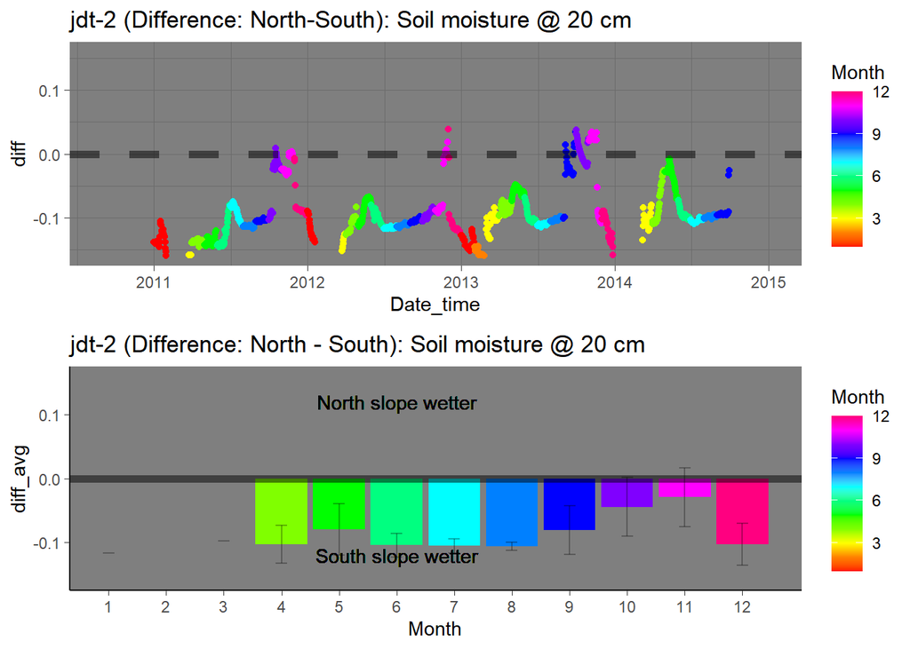

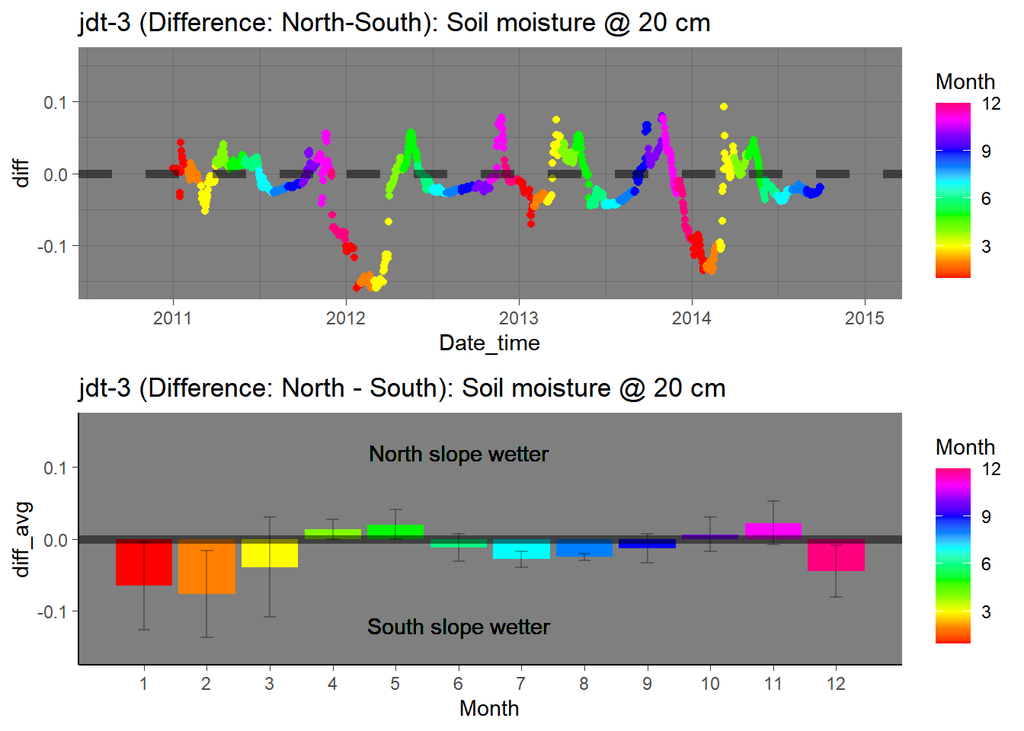

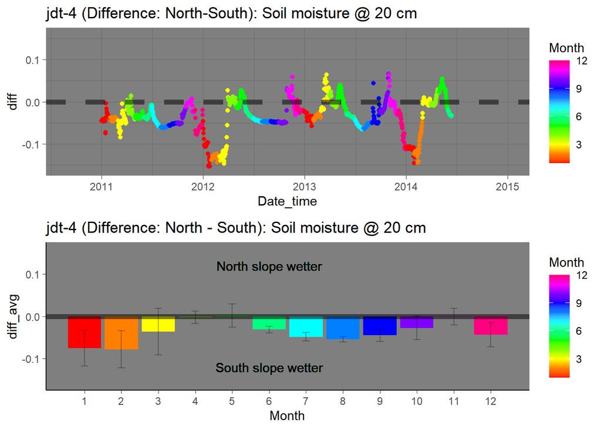

### What’s going on?

- Are the probe locations comparable?
- Plant water uptake?
- Data analysis error?

Johnston Draw Soil Moisture Probes

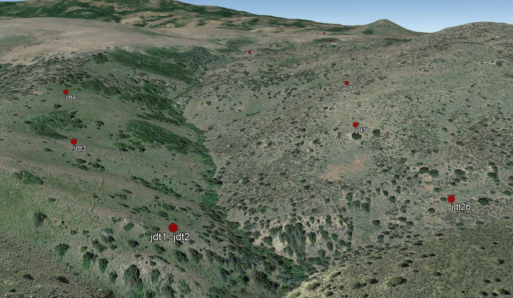

Soil Moisture Probe Locations

### Conclusion

- The goal here was to get isolate aspect effect on soil moisture, but the trend between moisture probes on opposing aspects is not as expected.
- Of note, the jdt2b and jdt4b probes are excluded in most ARS instrument maps. Perhaps there’s a known issue? Or it’s been previously recognized that the observed trend is unusual or unexplained?
- Godsey et al. says “For both WYs, water storage on north-facing slopes is on average 1.4 times greater and lasts longer than on south-facing slopes.”… Is that simply due to the ~50cm deeper soil depth on the north facing slopes? No explanation of this calculation is given in the manuscript.

##### So…where do we go with this data? Useful? Further analysis?

NOTE: There’s soil temp data included as well.

### Next up:

#### [Estimate of soil water inputs by elevation and aspect](http://example.com)

Derek Pierson Last modified: 11/21/20